# The GOAT Debate: Revealing the Greatest Basketball Player of All Time

Final Project  
Data Science 1 with R (STAT 301-1)

Author

Karthik Sathish

Published

December 6, 2023

**Github Repo Link**

[My Github Repo Link](https://github.com/stat301-1-2023-fall/final-project-1-kvsathish)

## Introduction

The following EDA stems from being a long-time fan of the NBA. From countless debates with people about the GOAT, I have thought long and hard about who is the greatest basketball player of all time.

### Overview

This overarching question is somewhat subjective based on your individual meaning of “great.” Not only have I looked into a range of factors that contribute to being the greatest, but I’ve also gotten into heated arguments with friends about who the GOAT of basketball is. Instead of simply pointing to the number of championships a player has won, I wanted to look into the statistics of all games played by Lebron James, Michael Jordan, and Kobe Bryant to justify who the best player is at the core of the game. I understand that longevity of a player’s career and injuries may influence the data, but I plan to account for any confounding variables based on my ball knowledge and further thorough research.

Personally, I have been one of the biggest Lebron James fans my whole life, but I plan to put biases aside to let the numbers decide who the greatest player of all time is. I understand that Lebron James, Michael Jordan, and Kobe Bryant have all culturally changed the game. However, I would like to simplify the argument for the greatest basketball player of all time by analyzing the raw statistics provided.

### Data Source

The source of my data is a user on `Kaggle.com`, named Xavier. Their username is `xvivancos`, and they are a data science enthusiast that is also a Kaggle Grandmaster. Their roots are from Barcelona and Catalonia, Spain. The archive of interest is named `Michael Jordan, Kobe Bryant and Lebron James stats`. In the EDA, I utilize a singular dataset called `allgames_stats` to compare the statistics from every game played by Lebron James, Michael Jordan, and Kobe Bryant. Some of my data analysis is also derived from a dataset called `totals_stats` to organize the data in a more general way. The `allgames_stats` is a great dataset that bypasses the idea of player longevity (an argument used in Lebron’s favor) by focusing on the first fifteen years of each player’s career. This way, performance at corresponding points in each player’s career can by compared to address the central question.

### Approaching the Central Question

My central question revolves around which of the three basketball players in the dataset is the greatest basketball player of all time. To approach this question, I’ve decided to evaluate it by who was the most valuable player the most times between the three individuals. The timeframe is restricted to the first fifteen seasons of each player’s respective career. This limits out the longevity arguments for players that have had longer careers than others. Now, I understand that the Most Valuable Player (MVP) in the NBA is often based on a player’s merit as well as team success. To assign the MVP to one of these three players in their first fifteen seasons, I have come up with my own metric for evaluation.

The MVP will be a much more statistically based award. This is because I will be using a variety of stats reflecting a player’s true impact over every single minute played during a season. To measure offensive output, I am including points, assists, and rebounds. For defensive output, I am additionally using steals and blocks. The specific `Score` for each player in a given season will be calculated by:

Score = (Points + Assists + Rebounds + Steals + Blocks) / Minutes Played

I am adjusting `Points` scored by each player to account for point inflation/deflation during time periods in the NBA. This is done with a normalization of points scored by each player to total points averaged by each of their respective teams in a given year.

Once this score is calculated for each game played in a given season for a player, the average of all the scores in a season will be computed as a final reflection for comparison. The greatest final mean score, each season, will justify who should’ve won the MVP. Then, I plan to add up MVPs for each player and deduce which player is the most valuable the most number of seasons.

Following the computation of each player’s score in their first fifteen seasons, I am going to evaluate it against turnovers and NBA GameScore to see how the score metric correlates with a variable reflecting negative player performance and with the overall efficiency score assigned to each player for a given game. Furthermore, I plan to also evaluate it against win totals in both the regular season and post season to see how effective the metric is with win success. I believe that this analysis justifies the quality of my score metric and who the greatest NBA player of all time is.

## Data Overview and Quality

The `allgames_stats` dataset is approximately 533 KB in size, and it is sufficiently complex for my analysis.

### Analyzing the data

In the dataset, there are 29 total variables and 4,254 total observations. Moreover, there are 6 categorical variables as well as 23 numerical variables. In terms of missingness, there is an issue for home games vs. away games.

### Issues in the data

In this dataset, home games are represented with `NA` values for the `X` variable. Also, some of the statistical percentages reflect `NA` values because zero attempts were made. This is often indicative of players missing a game due to injury or extenuating circumstanace. Another issue of missingness arises with the absence of GameScore values for Michael Jordan because it was a relatively new statistic during his early career. Sometimes, `NA` values would appear because some advanced statistics were not accounted for. Finally, an issue arises very rarely with the absence of a regular statistic like `Steals`. However, there is under a 0.260% rate of absence for values in similar variables.

### Cleaning the data

First, the `NA` values that indicated home vs. away games were inconsequential for my data analysis, so I ignored them. For statistical percentages, I also ignored `NA` values present because my analysis of player performance and output ignored efficiency statistics like percentage of field goals made. Instead, I am accounting for the `NA` values indicative of missed games and missing statistical percentages by utilizing `MP` or total minutes played in each game. This overcomes the absence of some values by narrowing the analysis to when each player was actively on the court. In order to use minutes played in the calculation of my score metric, I made sure to conver the `MP` variable from `difftime` type to a numeric type for effective manipulation of the corresponding data. The absence of GameScore values and regular statistical observations led to the removal of these minimal observations to clean out rare irregularities in the dataset for analysis.

## Explorations

### Analyzing key variables

#### Reasoning

To begin, I analyzed the most representative statistics for player performance in terms of offensive output and defensive output. The variables chosen were Points, Assists, Rebounds, Steals, and Blocks. These numbers reflect how a player contributed to winning in any given game. Also, I analyzed minutes played, so I could use this variable along with the five previous variables to calculate a score representative of a player’s performance whenever they were on the court.

#### Plots and analysis

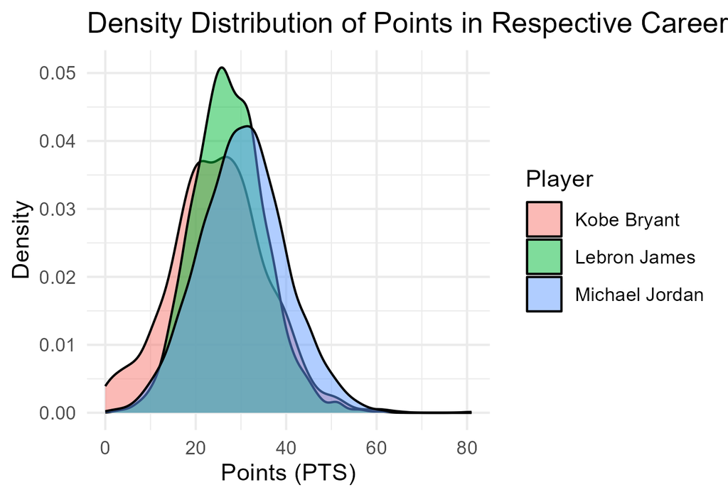

The density plot for points revealed the probability of scoring a certain number of points in any given game for an indicated player. According to this graph, Michael Jordan had the greatest center of distribution, meaning the addition of Points to the score metric would most benefit Jordan.

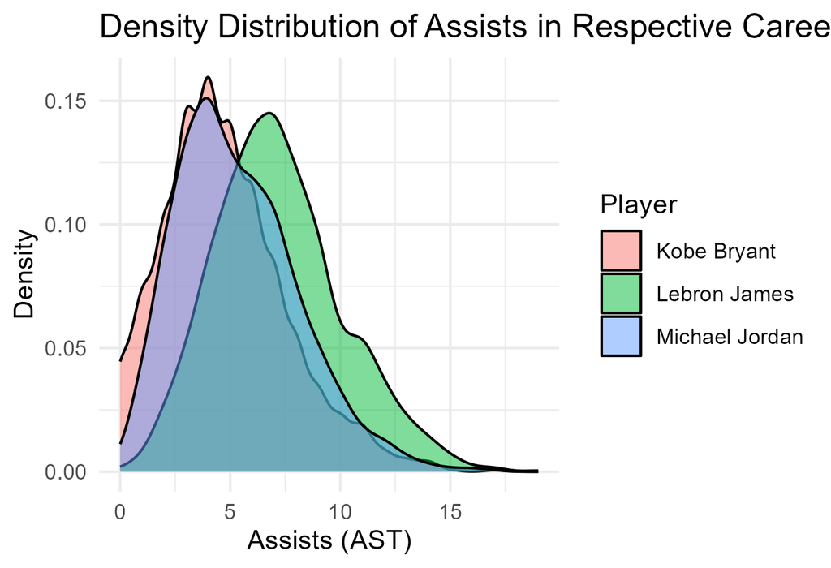

The density plot for assists revealed the probability of recording a certain number of assists in any given game for an indicated player. According to this graph, Lebron James had the greatest center of distribution, meaning the addition of Assists to the score metric would most benefit Lebron.

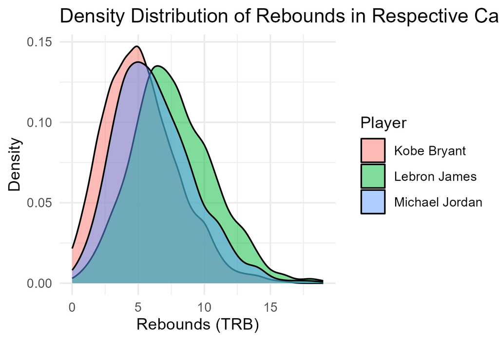

##### Summary Statistics of Steals by Player

| Player | mean_steals | min_steals | max_steals | total_steals |
| --- | --- | --- | --- | --- |
| Kobe Bryant | 1.439336 | 0 | 7 | 2254 |
| Lebron James | 1.639527 | 0 | 7 | 2356 |
| Michael Jordan | 2.256452 | 0 | 7 | 2798 |

The summary table for steals revealed the average steals recorded in a given game for an indicated player. According to the table, Michael Jordan had the greatest average steals, meaning the addition of Steals to the score metric would most benefit Jordan.

##### Summary Statistics of Blocks by Player

| Player | mean_blocks | min_blocks | max_blocks | total_blocks |
| --- | --- | --- | --- | --- |
| Kobe Bryant | 0.5006386 | 0 | 5 | 784 |
| Lebron James | 0.8023660 | 0 | 5 | 1153 |
| Michael Jordan | 0.8360000 | 0 | 5 | 1045 |

The summary table for blocks revealed the average blocks recorded in a given game for an indicated player. According to the table, Michael Jordan and Lebron James had a very similar average number of blocks, meaning the addition of Blocks to the score metric almost equally benefit Jordan and Lebron.

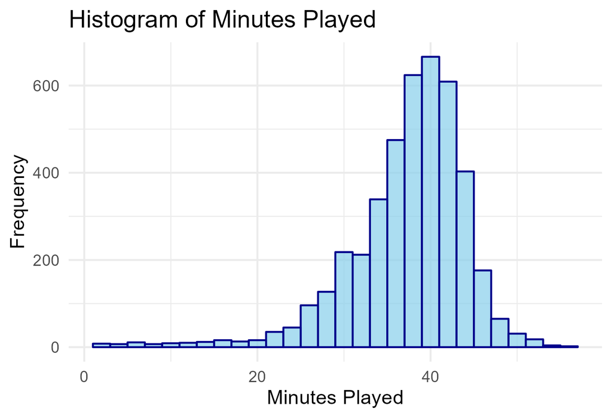

The histogram for minutes played revealed a unimodal, left-skewed distribution for all three players. The left skew can be attributed to early games in each player’s career, where they each had to fight for minutes. However, the mode lies nearby the center of the distribution at approximately 40 minutes, indicating that all three players normally played around 40 minutes per game.

#### Reflection

Following the visualization of the important variables to be used in my Score metric, I noticed that the five variables seemed to benefit Lebron James and Michael Jordan somewhat equally. On the other hand, Kobe Bryant seemed to be lacking in each statistic. Because of each statistic values a unique but important part of the game, Points, Assists, Rebounds, Steals, and Blocks will be weighed equally on top of Minutes Played to reach a holistic score for the evaluation of MVP.

### Calculating and exploring the new score metric

First, I calculated the `Score` for each regular season game played by a selected player. Once the data manipulation was completed, I found the average score for each player by each season for the first 15 years in their respective careers. Then, I printed the scores to visualize which player was the most valuable for the most amount of seasons between the three legends.

##### Season 1 Scores

| Kobe_Mean_Score |
| --- |
| 1.872667 |

| Lebron_Mean_Score |
| --- |
| 2.418668 |

| Jordan_Mean_Score |
| --- |
| 2.868403 |

##### Season 2 Scores

| Kobe_Mean_Score |
| --- |
| 2.230667 |

| Lebron_Mean_Score |
| --- |
| 2.916321 |

| Jordan_Mean_Score |
| --- |
| 3.352912 |

##### Season 3 Scores

| Kobe_Mean_Score |
| --- |
| 2.295707 |

| Lebron_Mean_Score |
| --- |
| 3.097429 |

| Jordan_Mean_Score |
| --- |
| 3.362144 |

##### Season 4 Scores

| Kobe_Mean_Score |
| --- |
| 2.579664 |

| Lebron_Mean_Score |
| --- |
| 2.886781 |

| Jordan_Mean_Score |
| --- |
| 3.316294 |

##### Season 5 Scores

| Kobe_Mean_Score |
| --- |
| 2.725392 |

| Lebron_Mean_Score |
| --- |
| 3.292339 |

| Jordan_Mean_Score |
| --- |
| 3.379875 |

##### Season 6 Scores

| Kobe_Mean_Score |
| --- |
| 2.769355 |

| Lebron_Mean_Score |
| --- |
| 3.405618 |

| Jordan_Mean_Score |
| --- |
| 3.360431 |

##### Season 7 Scores

| Kobe_Mean_Score |
| --- |
| 3.085117 |

| Lebron_Mean_Score |
| --- |
| 3.386131 |

| Jordan_Mean_Score |
| --- |
| 3.342156 |

##### Season 8 Scores

| Kobe_Mean_Score |
| --- |
| 2.661654 |

| Lebron_Mean_Score |
| --- |
| 3.051334 |

| Jordan_Mean_Score |
| --- |
| 3.057779 |

##### Season 9 Scores

| Kobe_Mean_Score |
| --- |
| 2.821794 |

| Lebron_Mean_Score |
| --- |
| 3.265621 |

| Jordan_Mean_Score |
| --- |
| 3.253653 |

##### Season 10 Scores

| Kobe_Mean_Score |
| --- |
| 3.232114 |

| Lebron_Mean_Score |
| --- |
| 3.22638 |

| Jordan_Mean_Score |
| --- |
| NaN |

##### Season 11 Scores

| Kobe_Mean_Score |
| --- |
| 2.993239 |

| Lebron_Mean_Score |
| --- |
| 3.105789 |

| Jordan_Mean_Score |
| --- |
| 2.994465 |

##### Season 12 Scores

| Kobe_Mean_Score |
| --- |
| 2.92227 |

| Lebron_Mean_Score |
| --- |
| 3.168911 |

| Jordan_Mean_Score |
| --- |
| 3.194031 |

##### Season 13 Scores

| Kobe_Mean_Score |
| --- |
| 2.906312 |

| Lebron_Mean_Score |
| --- |
| 3.203643 |

| Jordan_Mean_Score |
| --- |
| 3.10158 |

##### Season 14 Scores

| Kobe_Mean_Score |
| --- |
| 2.704552 |

| Lebron_Mean_Score |
| --- |
| 3.13299 |

| Jordan_Mean_Score |
| --- |
| 2.879944 |

##### Season 15 Scores

| Kobe_Mean_Score |
| --- |
| 2.977905 |

| Lebron_Mean_Score |
| --- |
| 3.406255 |

| Jordan_Mean_Score |
| --- |
| NaN |

According to the average score calculations by season for the first fifteen years of each players career, there is a tie between Lebron James and Michael Jordan. Both players have the highest average scores for seven separate seasons. For Michael Jordan, these seasons included 1-5, 8, and 12. Meanwhile, it encompassed seasons 6, 7, 9, 11, and 13-15 for Lebron James. Kobe Bryant only surpassed Lebron and Jordan in season 10 of their respective careers. One important observation is that Jordan lacked an average score in seasons 10 and 15 because of extenuating circumstances such as early retirement and an NBA lockout. To further extrapolate the greatest basketball player of all time, I plan to compare the newly-created `Score` variable with other factors that contribute to a player’s success.

#### Scores over time

In the following graphics, I am visualizing how the Score metric changed over time for each player.

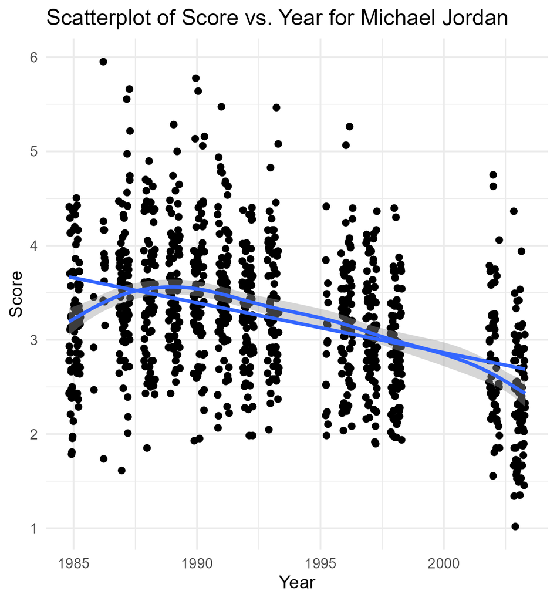

In this plot, both the smoothed trend line and the linear line of best fit reflect a moderately, negative relationship between `Year` and `Score`. It makes sense that Jordan’s Score began decreasing around 1990, because that it when Scottie Pippen was added to the team. This addition may have caused Jordan to be less valuable to the team as there was more help. There is further decrease around 1995 with the later addition of Dennis Rodman.

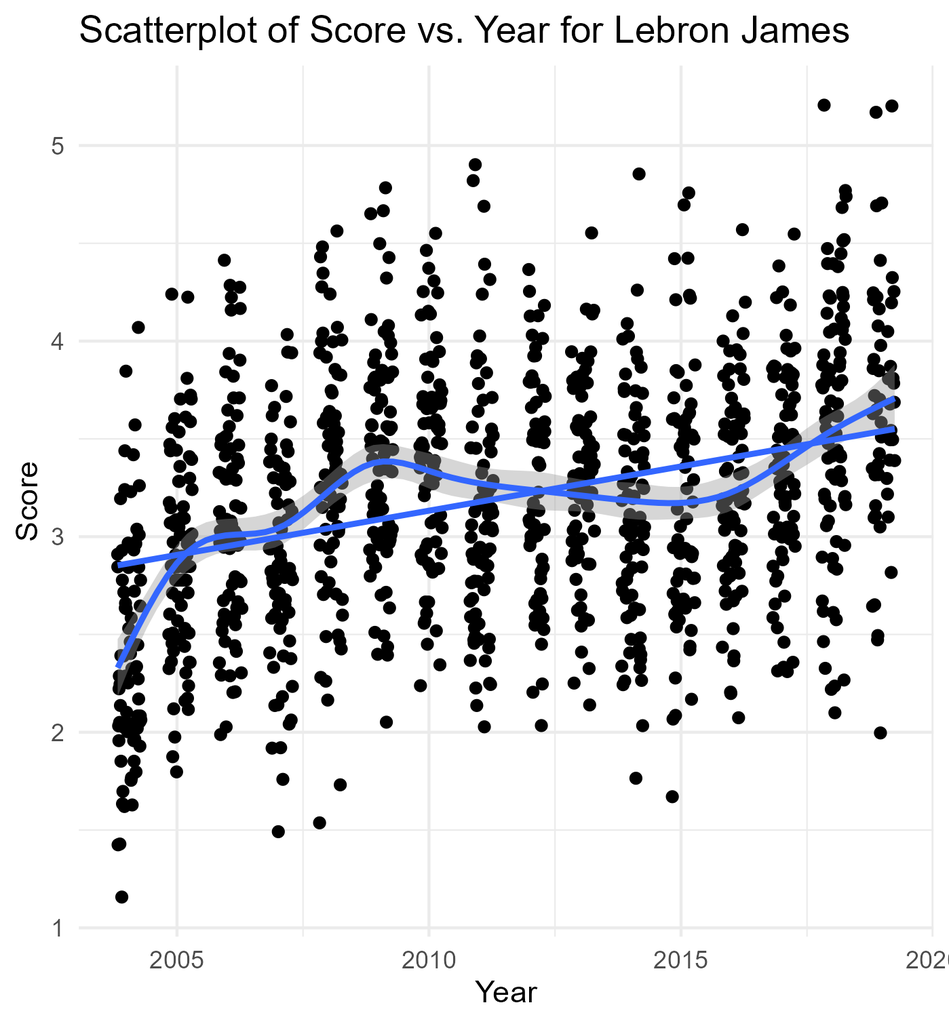

In this plot, the smoothed trend line is somewhat erratic through the course of Lebron’s career while the linear line of best fit reflects a moderately, positive relationship between `Year` and `Score`. This indicates that Lebron was generally more valuable to his team as he got older. The fact that Lebron’s greatest scores were found in season 15 are a true testament to his longevity. Since Lebron’s peak came at year 15, it is reasonable to assume Lebron has maintained his valuable contributions statistically 5 more years (to this day) than Jordan or Kobe.

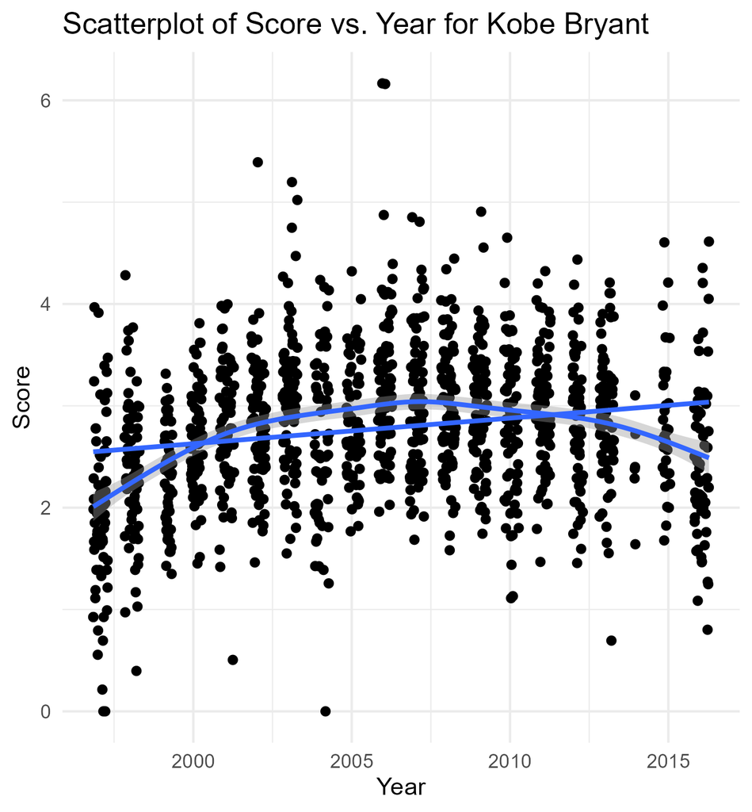

In this plot, the smoothed trend line is demonstrates Kobe Bryant had greater scores in the middle of his career, compared to the beginning and end. Meanwhile, the linear line of best fit reflects a weakly, positive relationship between `Year` and `Score`.

### Evaluating the score metric (multivariate analyses)

#### Validation measures

First, to test the credibility of the new score metric, I wanted to see if there was any relationship between a player’s `Score` and bad performance. One statistic that heavily relates to negative performance of a basketball player is turnovers. This is because turnovers most likely result from a corresponding player’s bad decision-making and results in an advantage for the opposing team. Below, I compare the turnovers by category to a distribution of Scores by each player.

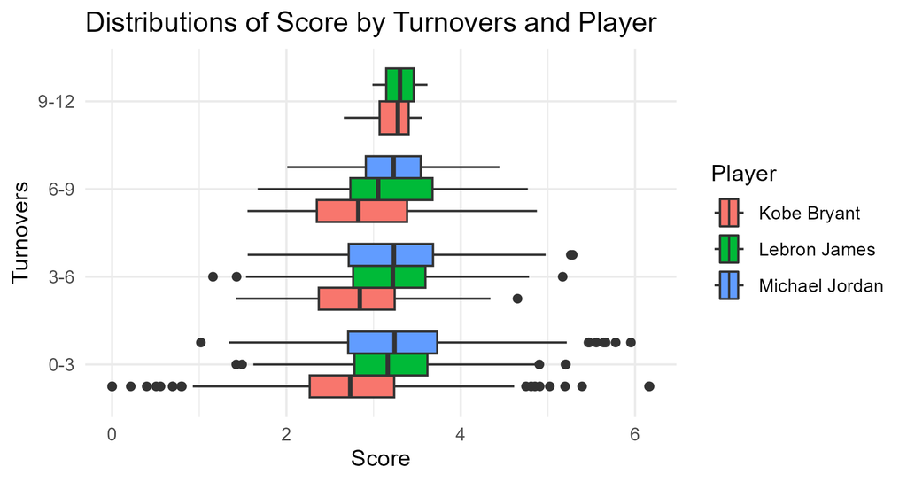

According to the plot, similar centers of distribution provide evidence that the score metric does not directly reflect a player’s negative performance. A higher score is not associated with more tunrovers. Furthermore, most of the IQRs lying from 2.5-3.5 indicates that the score metric remains consistent no matter how badly a player’s “decision-making” is. This validates the score metric because it is not associated with negative player performance.

Next, I am visualizing the relationship between the recorded NBA GameScore across games for each player and the new score metric. The NBA GameScore is a marker of player efficiency in a given game. It takes into account numerous statistics contributing to a game and properly weighs them in a final calculation. This provides as another test of validation to see if the new score metric can effectively measure how valuable a player is.

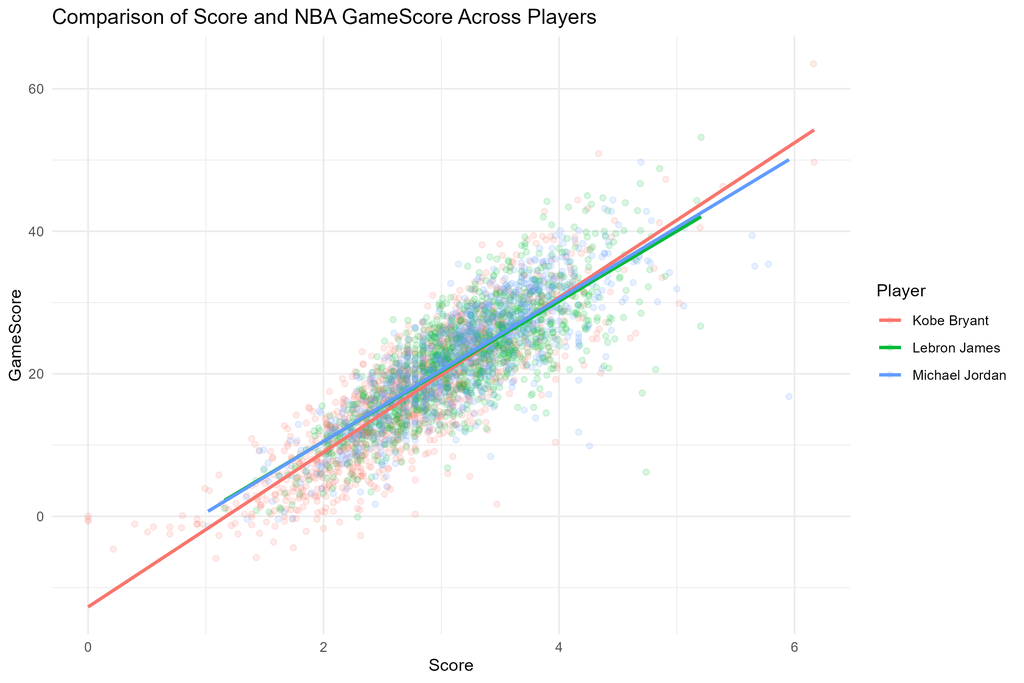

In the scatterplot above, the linear line of best fit for each player reflects a strongly, positive relationship between the Score and GameScore. Since there is directly proportional relationship and a relatively high correlation of points (seen by clustering), it can be noted that the Score is a validated measure of player performance.

#### Tie-breaker between Jordan and Lebron

Finally, I decided the best way to break the tie between Jordan and Lebron’s number of most valuable seasons is to quantify the win success in both the regular season and postseason according to their statisical contribution. This would be accomplished by comparing the new score metric to total wins. More wins correlating with greater Scores would prove who is the most valuable out of both for actual team success.

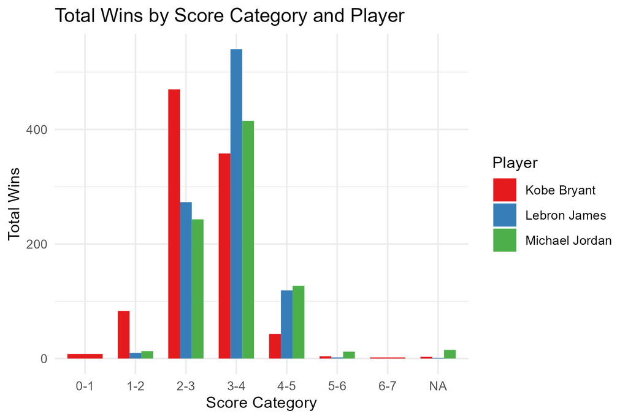

To ensure this graphic was not spreading misinformation, I also decided to look into the win totals between each of the players across the fifteen year span. Playing and winning a varied number of games could drastically impact the analysis. This led to searching for total games won by each player.

| Player | Win_Total |
| --- | --- |
| Kobe Bryant | 971 |
| Lebron James | 945 |
| Michael Jordan | 825 |

As indicated by the table, Kobe Bryant and Lebron James have much more games won than Michael Jordan. This could be attributed to Jordan’s early retirement as well as the NBA lockout in his last season. Wanting to normalize the win success across all three players, I diverted my focus to the proportion of total wins separated by scores given by the new metric.

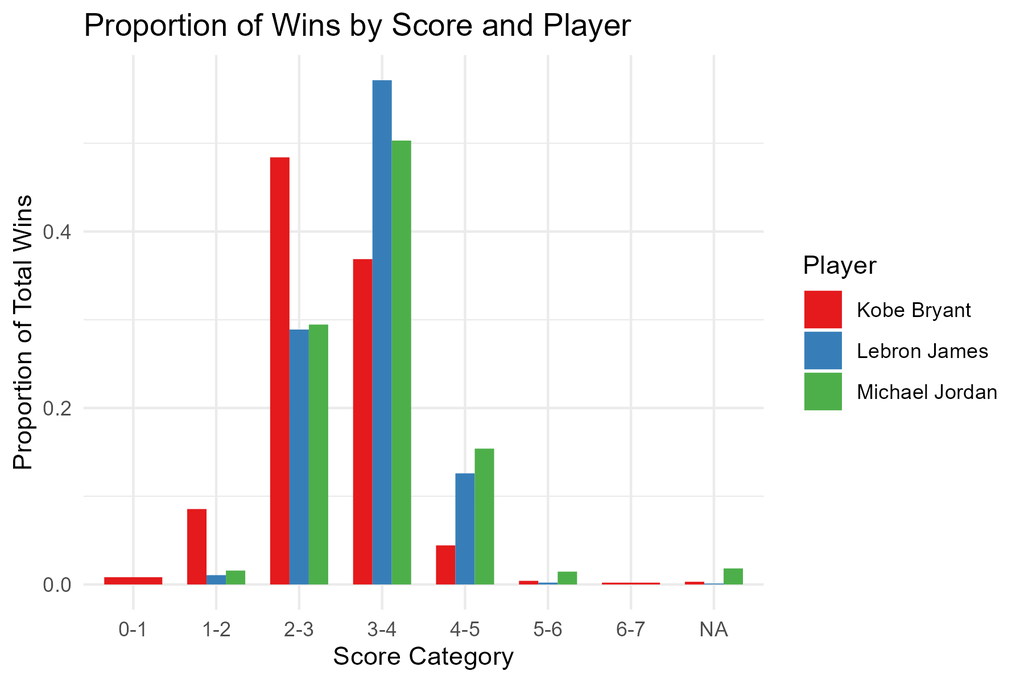

The final plot reveals a normalization of win success to properly analyze how much each player’s statistical contributions applied to winning games in the both the regular season and the playoffs. According to the graphic, Lebron James surpasses both Kobe Bryant and Michael Jordan in the proportion of total wins in the 3-4 Score category. This means that Lebron’s statistical contributions prove to be more valuable for winning than the other players. Although Jordan may have a slight edge in the 4-5 Score category, this difference along with that in the other Score categories are almost negligible. Also, these other categories are not as reflective of each player’s average performance in a given game.

## Conclusion

Overall, I am proud of the data analysis performed, but there is definitely room for improvement. One area that is tough to get around is adjusting to the varied play styles from the different eras that each player was involved in. Although I adjusted points scored by each player in a given game by comparing the average number of points scored by their respective teams in a selected season, the actual style of the game has shifted significantly in terms of strategy, defensive intensity, spacing, and scoring ability. In the future, it would be essential to meticulously weigh different statistics to adjust to different time periods. Also, it would be very interesting to see how the score metric changes during the playoffs for each player as well as how much each player actually contributes to postseason success.

## References

The dataset for analysis is named `Michael Jordan, Kobe Bryant and Lebron James stats`[^1]. Although all the stats were compiled by Xavier, the raw statistical data is from Basketball Reference[^2].

## Footnotes

[^1]: Found on https://www.kaggle.com/datasets/xvivancos/michael-jordan-kobe-bryant-and-lebron-james-stats/data?select=per_game_stats.csv
[^2]: Found on https://www.basketball-reference.com/